# Assignment 3: Verify the Claim of Povery Change in Philadelphia

Testing a published claim about neighborhood change against the data behind it

Author

Tatar Anurakwongsri

Published

September 25, 2026

## Setup

```r
library(tidyverse)
library(tidycensus)
library(sf)
library(ggplot2)
```

## Part 1 — Reconstruct

```r
vars <- c(total_poverty = "B17001_002",
               total_pop = "B01003_001",
               median_income = "B19013_001"
               )

data_2006 <- get_acs(
  geography = "tract",
  variables = vars,
  state = "PA",
  county = "Philadelphia",
  year = 2010,
  survey = "acs5",
  geometry = TRUE,
  output    = "wide"
)
data_2006 <- data_2006 %>%
  st_as_sf(coords = c("lon", "lat"), crs = 4326)

data_2013 <- get_acs(
  geography = "tract",
  variables = vars,
  state = "PA",
  county = "Philadelphia",
  year = 2017,
  survey = "acs5",
  geometry = TRUE,
  output    = "wide"
)
data_2013 <- data_2013 %>%
  st_as_sf(coords = c("lon", "lat"), crs = 4326)
```

### Notes from Article

[Article link](https://whyy.org/articles/new-census-figures-on-philly-neighborhoods-show-inequality-high-numbers-of-whites-living-in-poverty/)

- Fairhill 61% poverty rate
- 12% –> 26% poverty rate in Eastwick
- 2% –> 19% poverty rate in Holmesburg
- Median household income of Tioga-Nicetown plummeted from 28,026 to 17,493

### Variables of Interest

- Poverty rate (total)
- Median household income

### Variable Codes

- total_poverty: B17001_002
- total_pop: B01003_001
- median_income: B19013_001

The article claims a 14% increase in poverty rate between the 2006-2010 and 2013-2017 ACS data in the neighborhood of Eastwick, a 17% increase in poverty rate in Holmesburg, a drop in median household income in Tioga-Nicetown, and a 61% poverty rate in Fairhill.

The article pointed variables of interest from the census tract: total poverty rate, white poverty rate, median household income, and white population. Data from the 5-year ACS (2006-2010 & 2013-2017) and 2016 1-year ACS were used. The article states using these data tables while referencing the 2016-2017 ACS as the then-newest census data. I assumed some of the time period for some of the claims: Fairhill, Holmesburg, Tioga-Nicetown and the income gap. No years were specified for these so I assumed 2013-2017 based on the title. The time periods that overlap are 2013-2017 and 2016-2017. However, the 1-year ACS data is not available at the tract level due to the area 65,000 population requirement. The Census Bureau does not recommend comparing different time-period lengths as they measure characteristics of the population in different ways.

### Load Neighborhood Data

```r
github_path <- "https://raw.githubusercontent.com/opendataphilly/odp-data-storage/5c4538b5f4d2a26a81b7fab2d0006d327a39e3d0/philadelphia-neighborhoods/philadelphia-neighborhoods.geojson"

neighborhoods <- st_read(github_path)
neighborhoods <- st_make_valid(neighborhoods) # Fix broken geometry of neighborhoods

neighborhoods_2006 <- data_2006 %>%
  st_as_sf(coords = c("lon", "lat"), crs = 4326) %>%
  st_transform(st_crs(neighborhoods)) %>%
  st_join(neighborhoods) %>%
  st_drop_geometry()

neighborhoods_2013 <- data_2013 %>%
  st_as_sf(coords = c("lon", "lat"), crs = 4326) %>%
  st_transform(st_crs(neighborhoods)) %>%
  st_join(neighborhoods) %>%
  st_drop_geometry()
```

I used a new method from the sf package called st_make_valid to fix the geometry error during data import.

### Aggregate Data by Neighborhood

```r
grouped_neighborhoods_2006 <- neighborhoods_2006 %>%
  group_by(LISTNAME) %>%
  summarise(
    total_pop = sum(total_popE, na.rm = TRUE),
    total_pop_moe = moe_sum(moe = total_popM, estimate = total_popE, na.rm = TRUE),

    total_poverty = sum(total_povertyE, na.rm = TRUE),
    total_poverty_moe = moe_sum(moe = total_povertyM, estimate = total_povertyE, na.rm = TRUE),

    median_income = sum(median_incomeE, na.rm = TRUE),
    median_income_moe = moe_sum(moe = median_incomeM, estimate = median_incomeE, na.rm = TRUE)
  )

grouped_neighborhoods_2013 <- neighborhoods_2013 %>%
  group_by(LISTNAME) %>%
  summarise(
    total_pop = sum(total_popE, na.rm = TRUE),
    total_pop_moe = moe_sum(moe = total_popM, estimate = total_popE, na.rm = TRUE),

    total_poverty = sum(total_povertyE, na.rm = TRUE),
    total_poverty_moe = moe_sum(moe = total_povertyM, estimate = total_povertyE, na.rm = TRUE),

    median_income = sum(median_incomeE, na.rm = TRUE),
    median_income_moe = moe_sum(moe = median_incomeM, estimate = median_incomeE, na.rm = TRUE)
  )
```

## Part 2: Test

### Calculate Poverty Rate

```r
grouped_neighborhoods_2006 <- grouped_neighborhoods_2006 %>%
  mutate(pov_rate = (total_poverty / total_pop) * 100,
         pov_rate_moe = moe_prop(total_poverty, total_pop, total_poverty_moe, total_pop_moe),
         pov_moe_pct = (pov_rate_moe / pov_rate) * 100) %>%
  mutate(reliability = case_when(
  pov_moe_pct < 12  ~ "High",
  pov_moe_pct < 40 ~ "Moderate",
  TRUE         ~ "Low"
  ))

grouped_neighborhoods_2013 <- grouped_neighborhoods_2013 %>%
  mutate(pov_rate = (total_poverty / total_pop) * 100,
         pov_rate_moe = moe_prop(total_poverty, total_pop, total_poverty_moe, total_pop_moe),
         pov_moe_pct = (pov_rate_moe / pov_rate) * 100) %>%
  mutate(reliability = case_when(
  pov_moe_pct < 12  ~ "High",
  pov_moe_pct < 40 ~ "Moderate",
  TRUE         ~ "Low"
  ))
```

### View Reliability of Each Neighborhood as a Data Table

```r
library(gt)

reliability_table <- grouped_neighborhoods_2006 %>%
  mutate(
    dot = case_when(
      pov_moe_pct < 12  ~ "🟢",
      pov_moe_pct <= 40 ~ "🟡",
      TRUE              ~ "🔴"
    ),
    flag = case_when(
      pov_moe_pct < 12  ~ "Reliable",
      pov_moe_pct <= 40 ~ "Somewhat reliable",
      TRUE              ~ "Unreliable"
    ),
  ) %>%
  arrange(desc(pov_moe_pct)) %>%
  select(dot, LISTNAME, pov_rate, pov_rate_moe, pov_moe_pct, flag)

reliability_table %>%
  gt() %>%
  fmt_number(columns = c(pov_rate, pov_rate_moe), decimals = 0) %>%
  fmt_number(columns = pov_moe_pct, decimals = 1) %>%
  cols_label(
    dot               = "",
    LISTNAME          = "Neighborhood",
    pov_rate          = "Poverty Rate",
    pov_rate_moe      = "MOE",
    pov_moe_pct       = "CV (%)",
    flag              = "Reliability"
  ) %>%
  cols_align(align = "center", columns = dot) %>%
  tab_header(
    title    = "Population below 100% of the poverty level",
    subtitle = "Philadelphia Neighborhoods, ACS 2006-2010 5-year estimates"
  ) %>%
  tab_source_note(
    "Reliability thresholds follow Jurjevich et al. (2018): CV < 12% reliable, 12–40% somewhat reliable, > 40% unreliable."
  )
```

Population below 100% of the poverty level

Philadelphia Neighborhoods, ACS 2006-2010 5-year estimates

|  | Neighborhood | Poverty Rate | MOE | CV (%) | Reliability |
| --- | --- | --- | --- | --- | --- |
| 🟢 | Wissahickon Hills | 3 | 0 | 0.9 | Reliable |
| 🟢 | Mechanicsville | 8 | 0 | 0.6 | Reliable |
| 🟢 | Penrose | 7 | 0 | 0.6 | Reliable |
| 🟢 | Blue Bell Hill | 12 | 0 | 0.5 | Reliable |
| 🟢 | Pennypack Woods | 8 | 0 | 0.5 | Reliable |
| 🟢 | Andorra | 6 | 0 | 0.5 | Reliable |
| 🟢 | Dearnley Park | 10 | 0 | 0.5 | Reliable |
| 🟢 | Navy Yard | 16 | 0 | 0.5 | Reliable |
| 🟢 | Packer Park | 16 | 0 | 0.5 | Reliable |
| 🟢 | Winchester Park | 8 | 0 | 0.4 | Reliable |
| 🟢 | Aston-Woodbridge | 8 | 0 | 0.4 | Reliable |
| 🟢 | Normandy Village | 11 | 0 | 0.4 | Reliable |
| 🟢 | Franklin Mills | 7 | 0 | 0.4 | Reliable |
| 🟢 | Millbrook | 7 | 0 | 0.4 | Reliable |
| 🟢 | Eastwick | 12 | 0 | 0.4 | Reliable |
| 🟢 | West Torresdale | 8 | 0 | 0.4 | Reliable |
| 🟢 | Chinatown | 17 | 0 | 0.4 | Reliable |
| 🟢 | Chestnut Hill | 7 | 0 | 0.3 | Reliable |
| 🟢 | Wissahickon | 15 | 0 | 0.3 | Reliable |
| 🟢 | Germany Hill | 7 | 0 | 0.3 | Reliable |
| 🟢 | Roxborough Park | 7 | 0 | 0.3 | Reliable |
| 🟢 | Crestmont Farms | 7 | 0 | 0.3 | Reliable |
| 🟢 | Academy Gardens | 7 | 0 | 0.3 | Reliable |
| 🟢 | Byberry | 9 | 0 | 0.3 | Reliable |
| 🟢 | Cedarbrook | 9 | 0 | 0.3 | Reliable |
| 🟢 | Mount Airy, West | 11 | 0 | 0.3 | Reliable |
| 🟢 | Port Richmond | 21 | 0 | 0.3 | Reliable |
| 🟢 | Lexington Park | 9 | 0 | 0.3 | Reliable |
| 🟢 | Parkwood Manor | 9 | 0 | 0.3 | Reliable |
| 🟢 | Burholme | 10 | 0 | 0.3 | Reliable |

[output cut: 129 more lines]

Reliability thresholds follow Jurjevich et al. (2018): CV < 12% reliable, 12–40% somewhat reliable, > 40% unreliable.

```r
reliability_table <- grouped_neighborhoods_2013 %>%
  mutate(
    dot = case_when(
      pov_moe_pct < 12  ~ "🟢",
      pov_moe_pct <= 40 ~ "🟡",
      TRUE              ~ "🔴"
    ),
    flag = case_when(
      pov_moe_pct < 12  ~ "Reliable",
      pov_moe_pct <= 40 ~ "Somewhat reliable",
      TRUE              ~ "Unreliable"
    ),
  ) %>%
  arrange(desc(pov_moe_pct)) %>%
  select(dot, LISTNAME, pov_rate, pov_rate_moe, pov_moe_pct, flag)

reliability_table %>%
  gt() %>%
  fmt_number(columns = c(pov_rate, pov_rate_moe), decimals = 0) %>%
  fmt_number(columns = pov_moe_pct, decimals = 1) %>%
  cols_label(
    dot               = "",
    LISTNAME          = "Neighborhood",
    pov_rate          = "Poverty Rate",
    pov_rate_moe      = "MOE",
    pov_moe_pct       = "CV (%)",
    flag              = "Reliability"
  ) %>%
  cols_align(align = "center", columns = dot) %>%
  tab_header(
    title    = "Population below 100% of the poverty level",
    subtitle = "Philadelphia Neighborhoods, ACS 2006-2010 5-year estimates"
  ) %>%
  tab_source_note(
    "Reliability thresholds follow Jurjevich et al. (2018): CV < 12% reliable, 12–40% somewhat reliable, > 40% unreliable."
  )
```

Population below 100% of the poverty level

|  | Neighborhood | Poverty Rate | MOE | CV (%) | Reliability |
| --- | --- | --- | --- | --- | --- |
| 🟢 | Mechanicsville | 6 | 0 | 0.7 | Reliable |
| 🟢 | Navy Yard | 2 | 0 | 0.6 | Reliable |
| 🟢 | Packer Park | 2 | 0 | 0.6 | Reliable |
| 🟢 | Wissahickon Hills | 8 | 0 | 0.4 | Reliable |
| 🟢 | Franklin Mills | 8 | 0 | 0.4 | Reliable |
| 🟢 | Millbrook | 8 | 0 | 0.4 | Reliable |
| 🟢 | Andorra | 12 | 0 | 0.4 | Reliable |
| 🟢 | Pennypack Woods | 9 | 0 | 0.4 | Reliable |
| 🟢 | Crestmont Farms | 6 | 0 | 0.4 | Reliable |
| 🟢 | Winchester Park | 8 | 0 | 0.4 | Reliable |
| 🟢 | Germany Hill | 10 | 0 | 0.3 | Reliable |
| 🟢 | Roxborough Park | 10 | 0 | 0.3 | Reliable |
| 🟢 | Normandy Village | 15 | 0 | 0.3 | Reliable |
| 🟢 | Penrose | 32 | 0 | 0.3 | Reliable |
| 🟢 | Dearnley Park | 16 | 0 | 0.3 | Reliable |
| 🟢 | Aston-Woodbridge | 10 | 0 | 0.3 | Reliable |
| 🟢 | West Torresdale | 8 | 0 | 0.3 | Reliable |
| 🟢 | Blue Bell Hill | 14 | 0 | 0.3 | Reliable |
| 🟢 | Lexington Park | 16 | 0 | 0.3 | Reliable |
| 🟢 | Burholme | 18 | 0 | 0.3 | Reliable |
| 🟢 | Cedarbrook | 12 | 0 | 0.3 | Reliable |
| 🟢 | Wissahickon | 18 | 0 | 0.3 | Reliable |
| 🟢 | Byberry | 9 | 0 | 0.3 | Reliable |
| 🟢 | Port Richmond | 20 | 0 | 0.2 | Reliable |
| 🟢 | Pennsport | 18 | 0 | 0.2 | Reliable |
| 🟢 | Upper Roxborough | 10 | 0 | 0.2 | Reliable |
| 🟢 | Callowhill | 21 | 0 | 0.2 | Reliable |
| 🟢 | Academy Gardens | 9 | 0 | 0.2 | Reliable |
| 🟢 | Yorktown | 28 | 0 | 0.2 | Reliable |
| 🟢 | Chestnut Hill | 6 | 0 | 0.2 | Reliable |

[output cut: 129 more lines]

Reliability thresholds follow Jurjevich et al. (2018): CV < 12% reliable, 12–40% somewhat reliable, > 40% unreliable.

### Calculate change between two time periods and margin of error of this change

```r
selected_2006 <- select(grouped_neighborhoods_2006,
                        c(LISTNAME, pov_rate_2006 = pov_rate, pov_moe_2006 = pov_rate_moe,
                          median_income_2006 = median_income, income_moe_2006 = median_income_moe))
selected_2013 <- select(grouped_neighborhoods_2013,
                        c(LISTNAME, pov_rate_2013 = pov_rate, pov_moe_2013 = pov_rate_moe,
                          median_income_2013 = median_income, income_moe_2013 = median_income_moe))

comparison_df <- inner_join(selected_2006,selected_2013, by = "LISTNAME") %>%
  na.omit(comparison_df)

pov_comparison <- comparison_df %>%
  mutate(
    pov_change = pov_rate_2013 - pov_rate_2006,
    se_1     = pov_moe_2013 / 1.645,
    se_2     = pov_moe_2006 / 1.645,
    se_diff  = sqrt(se_1^2 + se_2^2),
    moe_diff = se_diff * 1.645,
    z        = pov_change / se_diff,
    significant = abs(z) > 1.645
  )

income_comparison <- comparison_df %>%
  mutate(
    income_change = median_income_2013 - median_income_2006,
    se_1     = income_moe_2013 / 1.645,
    se_2     = income_moe_2006 / 1.645,
    se_diff  = sqrt(se_1^2 + se_2^2),
    moe_diff = se_diff * 1.645,
    z        = income_change / se_diff,
    significant = abs(z) > 1.645
  )

pov_comparison %>%
  count(significant)
```

```
# A tibble: 1 × 2
  significant     n
  <lgl>       <int>
1 TRUE          158
```

### View Biggest Percent Changes

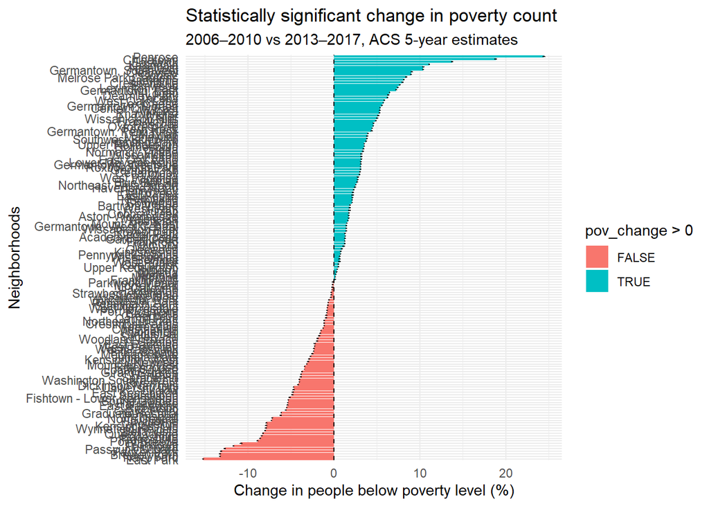

```r
pov_comparison %>%
  filter(significant) %>%
  ggplot(aes(x = reorder(LISTNAME, pov_change), y = pov_change)) +
  geom_col(aes(fill = pov_change > 0)) +
  geom_errorbar(aes(ymin = pov_change - moe_diff,
                    ymax = pov_change + moe_diff), width = 0.3) +
  geom_hline(yintercept = 0, linetype = "dashed") +
  coord_flip() +
  theme_minimal() +
  labs(title = "Statistically significant change in poverty count",
       subtitle = "2006–2010 vs 2013–2017, ACS 5-year estimates",
       x = "Neighborhoods", y = "Change in people below poverty level (%)")
```

The only neighborhood that produce NAs was the airport, because its population and poverty columns were 0 due to no one living there. Division with 0 will produce NAs as it is not possible. Because it was the only neighborhood that had an NA, I removed it from the comparison data frame. If there had been more neighborhoods with NAs, I would explore ACS data sets from other years to find more complete data.

## Part 3: Adjudicate

### Poverty-Related Claims

```r
pov_comparison %>%
  filter(LISTNAME == 'Eastwick')
```

```
# A tibble: 1 × 16
  LISTNAME pov_rate_2006 pov_moe_2006 median_income_2006 income_moe_2006
  <chr>            <dbl>        <dbl>              <dbl>           <dbl>
1 Eastwick          11.8       0.0440             245827          29535.
# ℹ 11 more variables: pov_rate_2013 <dbl>, pov_moe_2013 <dbl>,
#   median_income_2013 <dbl>, income_moe_2013 <dbl>, pov_change <dbl>,
#   se_1 <dbl>, se_2 <dbl>, se_diff <dbl>, moe_diff <dbl>, z <dbl>,
#   significant <lgl>
```

```r
pov_comparison %>%
  filter(LISTNAME == 'Holmesburg')
```

```
# A tibble: 1 × 16
  LISTNAME   pov_rate_2006 pov_moe_2006 median_income_2006 income_moe_2006
  <chr>              <dbl>        <dbl>              <dbl>           <dbl>
1 Holmesburg          14.3       0.0247             397548          28031.
# ℹ 11 more variables: pov_rate_2013 <dbl>, pov_moe_2013 <dbl>,
#   median_income_2013 <dbl>, income_moe_2013 <dbl>, pov_change <dbl>,
#   se_1 <dbl>, se_2 <dbl>, se_diff <dbl>, moe_diff <dbl>, z <dbl>,
#   significant <lgl>
```

```r
pov_comparison %>%
  filter(LISTNAME == 'Fairhill')
```

```
# A tibble: 1 × 16
  LISTNAME pov_rate_2006 pov_moe_2006 median_income_2006 income_moe_2006
  <chr>            <dbl>        <dbl>              <dbl>           <dbl>
1 Fairhill          53.6       0.0381             129856          14306.
# ℹ 11 more variables: pov_rate_2013 <dbl>, pov_moe_2013 <dbl>,
#   median_income_2013 <dbl>, income_moe_2013 <dbl>, pov_change <dbl>,
#   se_1 <dbl>, se_2 <dbl>, se_diff <dbl>, moe_diff <dbl>, z <dbl>,
#   significant <lgl>
```

### Income-related claims

```r
income_comparison %>%
  filter(LISTNAME %in% c("Tioga", "Nicetown"))
```

```
# A tibble: 2 × 16
  LISTNAME pov_rate_2006 pov_moe_2006 median_income_2006 income_moe_2006
  <chr>            <dbl>        <dbl>              <dbl>           <dbl>
1 Nicetown          30.0       0.0542              99815           9568.
2 Tioga             32.1       0.0334             307688          29974.
# ℹ 11 more variables: pov_rate_2013 <dbl>, pov_moe_2013 <dbl>,
#   median_income_2013 <dbl>, income_moe_2013 <dbl>, income_change <dbl>,
#   se_1 <dbl>, se_2 <dbl>, se_diff <dbl>, moe_diff <dbl>, z <dbl>,
#   significant <lgl>
```

1. Claims that are supported

The poverty rate in Eastwick did indeed increased from 12% to 26% between the 2006-2010 and 2013-2017 ACS. The high reliability also indicates this statistic is trustworthy.

2. Claims that are unsupported

Fairhill did not have a 61% poverty rate in either ACS data sets, as the poverty rate hovered around 55%. The Holmesburg claim is completely wrong. The poverty rate was never 2% and never reach the 19% as the article suggests. Its poverty rate was 14% in 2006-2010 and increased significantly to ~18% in 2013-2017. Lastly, the median income of Nicetown decreased significantly, but did not match the figures the article suggested. In 2006-2010, the median household income of Nicetown was 99,815, decreasing to 72,443 by the time of the next 5-year ACS. Tioga had a median household income of 307,688 in 2006-2010, declining to 296,165 by 2013-2017, which was an insignificant decrease.

## Part 4: Rewrite

Between the 2006-2010 and 2013-2017 ACS data sets, the Eastwick neighborhood experienced a poverty rate increase from 12% to 26%, which was statistically significant. Holemesburg saw a 4% increase in its poverty rate, which was significant in the neighborhood’s context. Fairhill had a high, but consistent poverty rate of 55% across the two ACS time spans. Lastly, both Tioga and Nicetown experienced a decrease in median income: 307,688 to 296,165 for the former and 99,815 to 72,443 for the latter. Due to the high median income in Tioga, this was not a significant change. However, the decrease in income was significant for Nicetown.